# indicios de feminicidio

ENRIQUE

19/7/2020

# Metodo de Clasificacion Logit Probit

con la base de datos de mujeres casadas

Cargando la base de datos

```r
load("C:\\Users\\Dell\\Documents\\GitHub\\mi_proyecto1_EST_384\\proy_MineriaDatos\\bd_proy\\bd_cas.RData")
```

preprando la base de datos

```r
library(dplyr)
aux<-seq(284,347,3)

bd_lp<-bd_cas %>% dplyr::select(aux)
str(bd_lp)
```

```
## 'data.frame':    4880 obs. of  22 variables:
##  $ S3_10_01: Factor w/ 6 levels "1. Muchas veces",..: 2 4 4 4 4 4 4 4 4 4 ...
##  $ S3_10_02: Factor w/ 6 levels "1. Muchas veces",..: 4 4 2 4 4 4 4 4 4 4 ...
##  $ S3_10_03: Factor w/ 6 levels "1. Muchas veces",..: 4 4 4 4 4 4 4 4 4 4 ...
##  $ S3_10_04: Factor w/ 6 levels "1. Muchas veces",..: 2 4 4 4 4 4 4 4 4 4 ...
##  $ S3_10_05: Factor w/ 6 levels "1. Muchas veces",..: 2 4 4 4 4 4 4 4 4 4 ...
##  $ S3_10_06: Factor w/ 6 levels "1. Muchas veces",..: 4 4 4 4 6 4 4 4 4 4 ...
##  $ S3_10_07: Factor w/ 6 levels "1. Muchas veces",..: 4 4 4 4 4 4 4 4 4 4 ...
##  $ S3_10_08: Factor w/ 6 levels "1. Muchas veces",..: 4 4 4 4 4 5 4 4 4 4 ...
##  $ S3_10_09: Factor w/ 6 levels "1. Muchas veces",..: 4 4 4 4 4 4 4 4 4 4 ...
##  $ S3_10_10: Factor w/ 6 levels "1. Muchas veces",..: 4 4 4 4 4 4 4 4 4 4 ...
##  $ S3_10_11: Factor w/ 6 levels "1. Muchas veces",..: 4 4 4 4 4 4 4 4 4 4 ...
##  $ S3_10_12: Factor w/ 6 levels "1. Muchas veces",..: 4 4 4 4 4 4 4 4 4 4 ...
##  $ S3_10_13: Factor w/ 6 levels "1. Muchas veces",..: 2 4 4 4 4 3 4 4 4 4 ...
##  $ S3_10_14: Factor w/ 6 levels "1. Muchas veces",..: 4 4 4 4 4 4 4 4 4 4 ...
##  $ S3_10_15: Factor w/ 6 levels "1. Muchas veces",..: 2 4 4 4 4 4 4 4 4 4 ...
##  $ S3_10_16: Factor w/ 6 levels "1. Muchas veces",..: 4 4 4 4 4 4 4 4 4 4 ...
##  $ S3_10_17: Factor w/ 6 levels "1. Muchas veces",..: 4 4 4 4 4 4 4 4 4 4 ...
##  $ S3_10_18: Factor w/ 6 levels "1. Muchas veces",..: 4 4 4 4 4 4 4 4 4 4 ...
##  $ S3_10_19: Factor w/ 6 levels "1. Muchas veces",..: 4 4 4 4 4 4 4 4 4 4 ...
##  $ S3_10_20: Factor w/ 6 levels "1. Muchas veces",..: 4 4 4 4 4 4 4 4 4 4 ...
##  $ S3_10_21: Factor w/ 6 levels "1. Muchas veces",..: 3 4 4 4 4 4 4 4 4 4 ...
##  $ S3_10_22: Factor w/ 6 levels "1. Muchas veces",..: 4 4 4 4 4 4 4 4 4 4 ...
```

```r
Hmisc::describe(bd_lp)
```

```
## bd_lp
##
##  22  Variables      4880  Observations
## --------------------------------------------------------------------------------
## S3_10_01
##        n  missing distinct
##     4880        0        6
##
## lowest : 1. Muchas veces 2. Pocas veces  3. Una vez      4. No ocurrió   5. No recuerda
## highest: 2. Pocas veces  3. Una vez      4. No ocurrió   5. No recuerda  6. No aplica
##
## Value      1. Muchas veces  2. Pocas veces      3. Una vez   4. No ocurrió
## Frequency             1235            1401             272            1921
## Proportion           0.253           0.287           0.056           0.394
##
## Value       5. No recuerda    6. No aplica
## Frequency               43               8
## Proportion           0.009           0.002
## --------------------------------------------------------------------------------
## S3_10_02
##        n  missing distinct
##     4880        0        6
##
## lowest : 1. Muchas veces 2. Pocas veces  3. Una vez      4. No ocurrió   5. No recuerda
## highest: 2. Pocas veces  3. Una vez      4. No ocurrió   5. No recuerda  6. No aplica
##
## Value      1. Muchas veces  2. Pocas veces      3. Una vez   4. No ocurrió
## Frequency              761             965             409            2687
## Proportion           0.156           0.198           0.084           0.551
##
## Value       5. No recuerda    6. No aplica
## Frequency               53               5
## Proportion           0.011           0.001
## --------------------------------------------------------------------------------
## S3_10_03
##        n  missing distinct
##     4880        0        6
##
## lowest : 1. Muchas veces 2. Pocas veces  3. Una vez      4. No ocurrió   5. No recuerda
## highest: 2. Pocas veces  3. Una vez      4. No ocurrió   5. No recuerda  6. No aplica
```

[output cut: 279 more lines]

```
## S3_10_22
##        n  missing distinct
##     4880        0        6
##
## lowest : 1. Muchas veces 2. Pocas veces  3. Una vez      4. No ocurrió   5. No recuerda
## highest: 2. Pocas veces  3. Una vez      4. No ocurrió   5. No recuerda  6. No aplica
##
## Value      1. Muchas veces  2. Pocas veces      3. Una vez   4. No ocurrió
## Frequency              109             167             148            4423
## Proportion           0.022           0.034           0.030           0.906
##
## Value       5. No recuerda    6. No aplica
## Frequency               24               9
## Proportion           0.005           0.002
## --------------------------------------------------------------------------------
```

segun la investigacion del Doctor Cruz Guisbert Juan Richard, en su articulo que se basa a datos recopilados de caso de feminicidio en Bolivia en los años 2016 y 2017 segun datos proporcionados por la FELCV, las principales armas utilizadas en feminicidios fueron: * arma de fuego * arma blanca * contusiones * lazo * toxicos

la moyoria de estas caracteristicas se encuentran en las variables de nuestra bd_lp,las cuales son:

- S3_10_13 ¿Desde que inició la relación con su (ex) pareja/ (ex) novio, alguna vez él la ha abofeteado, golpeado con las manos o puños?
- S3_10_14 ¿Desde que inició la relación con su (ex) pareja/ (ex) novio, alguna vez él la ha golpeado con algún objeto?
- S3_10_15 ¿Desde que inició la relación con su (ex) pareja/ (ex) novio, alguna vez él la ha pateado?
- S3_10_16 ¿Desde que inició la relación con su (ex) pareja/ (ex) novio, alguna vez él la ha tratado de ahorcar o asfixiar?
- S3_10_18 ¿Desde que inició la relación con su (ex) pareja/ (ex) novio, alguna vez él la ha agredido con cuchillo, navaja, pistola o cualquier otra arma?
- S3_10_19 ¿Desde que inició la relación con su (ex) pareja/ (ex) novio, alguna vez él le ha disparado con un arma?

sea “y” una variable

Indicio de Feminicidio: por los menos sucedio una ves alguna de las variables ya mencionadas Indicios de Feminici: variable de tipo binario donde “y” es un posible indicador de indicios de feminicidio

```r
levels(bd_lp$S3_10_13)
```

```
## [1] "1. Muchas veces" "2. Pocas veces"  "3. Una vez"      "4. No ocurrió"
## [5] "5. No recuerda"  "6. No aplica"
```

```r
table(is.na(bd_lp))
```

```
##
##  FALSE
## 107360
```

```r
bd_lp<-bd_lp %>% mutate(fem1=S3_10_13=="1. Muchas veces"|S3_10_14=="1. Muchas veces"|S3_10_15=="1. Muchas veces"|S3_10_16=="1. Muchas veces"|S3_10_18=="1. Muchas veces"|S3_10_19=="1. Muchas veces")
bd_lp<-bd_lp %>% mutate(fem2=S3_10_13=="2. Pocas veces"|S3_10_14=="2. Pocas veces"|S3_10_15=="2. Pocas veces"|S3_10_16=="2. Pocas veces"|S3_10_18=="2. Pocas veces"|S3_10_19=="2. Pocas veces")
bd_lp<-bd_lp %>% mutate(fem3=S3_10_13=="3. Una vez"|S3_10_14=="3. Una vez"|S3_10_15=="3. Una vez"|S3_10_16=="3. Una vez"|S3_10_18=="3. Una vez"|S3_10_19=="3. Una vez")
bd_lp<-bd_lp %>% mutate(ind_feminicidio=(fem1==TRUE|fem2==TRUE|fem3==TRUE))
#bd_lp<-bd_lp %>% mutate(ind_feminicidio=(fem1==TRUE|fem2==TRUE))

aux2<-c("1. Muchas veces","2. Pocas veces","3. Una vez")

table(bd_lp$ind_feminicidio)
```

```
##
## FALSE  TRUE
##  2951  1929
```

```r
var_elim<-c("S3_10_13","S3_10_14","S3_10_15","S3_10_16","S3_10_18","S3_10_19","fem1","fem2","fem3")
#var_elim<-c("S3_10_13","S3_10_14","S3_10_15","S3_10_16","S3_10_18","S3_10_19","fem1","fem2")
Hmisc::describe(bd_lp)
```

```
## bd_lp
##
##  26  Variables      4880  Observations
## --------------------------------------------------------------------------------
## S3_10_01
##        n  missing distinct
##     4880        0        6
##
## lowest : 1. Muchas veces 2. Pocas veces  3. Una vez      4. No ocurrió   5. No recuerda
## highest: 2. Pocas veces  3. Una vez      4. No ocurrió   5. No recuerda  6. No aplica
##
## Value      1. Muchas veces  2. Pocas veces      3. Una vez   4. No ocurrió
## Frequency             1235            1401             272            1921
## Proportion           0.253           0.287           0.056           0.394
##
## Value       5. No recuerda    6. No aplica
## Frequency               43               8
## Proportion           0.009           0.002
## --------------------------------------------------------------------------------
## S3_10_02
##        n  missing distinct
##     4880        0        6
##
## lowest : 1. Muchas veces 2. Pocas veces  3. Una vez      4. No ocurrió   5. No recuerda
## highest: 2. Pocas veces  3. Una vez      4. No ocurrió   5. No recuerda  6. No aplica
##
## Value      1. Muchas veces  2. Pocas veces      3. Una vez   4. No ocurrió
## Frequency              761             965             409            2687
## Proportion           0.156           0.198           0.084           0.551
##
## Value       5. No recuerda    6. No aplica
## Frequency               53               5
## Proportion           0.011           0.001
## --------------------------------------------------------------------------------
## S3_10_03
##        n  missing distinct
##     4880        0        6
##
## lowest : 1. Muchas veces 2. Pocas veces  3. Una vez      4. No ocurrió   5. No recuerda
## highest: 2. Pocas veces  3. Una vez      4. No ocurrió   5. No recuerda  6. No aplica
```

[output cut: 311 more lines]

```
##        n  missing distinct
##     4880        0        2
##
## Value      FALSE  TRUE
## Frequency   3856  1024
## Proportion  0.79  0.21
## --------------------------------------------------------------------------------
## ind_feminicidio
##        n  missing distinct
##     4880        0        2
##
## Value      FALSE  TRUE
## Frequency   2951  1929
## Proportion 0.605 0.395
## --------------------------------------------------------------------------------
```

```r
bd_lp2<-bd_lp %>% dplyr::select(-var_elim)

Hmisc::describe(bd_lp2)
```

```
## bd_lp2
##
##  17  Variables      4880  Observations
## --------------------------------------------------------------------------------
## S3_10_01
##        n  missing distinct
##     4880        0        6
##
## lowest : 1. Muchas veces 2. Pocas veces  3. Una vez      4. No ocurrió   5. No recuerda
## highest: 2. Pocas veces  3. Una vez      4. No ocurrió   5. No recuerda  6. No aplica
##
## Value      1. Muchas veces  2. Pocas veces      3. Una vez   4. No ocurrió
## Frequency             1235            1401             272            1921
## Proportion           0.253           0.287           0.056           0.394
##
## Value       5. No recuerda    6. No aplica
## Frequency               43               8
## Proportion           0.009           0.002
## --------------------------------------------------------------------------------
## S3_10_02
##        n  missing distinct
##     4880        0        6
##
## lowest : 1. Muchas veces 2. Pocas veces  3. Una vez      4. No ocurrió   5. No recuerda
## highest: 2. Pocas veces  3. Una vez      4. No ocurrió   5. No recuerda  6. No aplica
##
## Value      1. Muchas veces  2. Pocas veces      3. Una vez   4. No ocurrió
## Frequency              761             965             409            2687
## Proportion           0.156           0.198           0.084           0.551
##
## Value       5. No recuerda    6. No aplica
## Frequency               53               5
## Proportion           0.011           0.001
## --------------------------------------------------------------------------------
## S3_10_03
##        n  missing distinct
##     4880        0        6
##
## lowest : 1. Muchas veces 2. Pocas veces  3. Una vez      4. No ocurrió   5. No recuerda
## highest: 2. Pocas veces  3. Una vez      4. No ocurrió   5. No recuerda  6. No aplica
```

[output cut: 197 more lines]

```
## Frequency              109             167             148            4423
## Proportion           0.022           0.034           0.030           0.906
##
## Value       5. No recuerda    6. No aplica
## Frequency               24               9
## Proportion           0.005           0.002
## --------------------------------------------------------------------------------
## ind_feminicidio
##        n  missing distinct
##     4880        0        2
##
## Value      FALSE  TRUE
## Frequency   2951  1929
## Proportion 0.605 0.395
## --------------------------------------------------------------------------------
```

volviendo a las demas variables binarias

```r
bd_lp2<-bd_lp2 %>% mutate(pal_gros=S3_10_01=="1. Muchas veces"|S3_10_01=="2. Pocas veces"|S3_10_01=="3. Una vez")

bd_lp2<-bd_lp2 %>% mutate(humillacion=S3_10_02=="1. Muchas veces"|S3_10_02=="2. Pocas veces"|S3_10_02=="3. Una vez")

bd_lp2<-bd_lp2 %>% mutate(prohib_sal=S3_10_03=="1. Muchas veces"|S3_10_03=="2. Pocas veces"|S3_10_03=="3. Una vez")

bd_lp2<-bd_lp2 %>% mutate(amenaza_last=S3_10_04=="1. Muchas veces"|S3_10_04=="2. Pocas veces"|S3_10_04=="3. Una vez")

bd_lp2<-bd_lp2 %>% mutate(amenaza_matar=S3_10_05=="1. Muchas veces"|S3_10_05=="2. Pocas veces"|S3_10_05=="3. Una vez")

bd_lp2<-bd_lp2 %>% mutate(quitar_hijos=S3_10_06=="1. Muchas veces"|S3_10_06=="2. Pocas veces"|S3_10_06=="3. Una vez")

bd_lp2<-bd_lp2 %>% mutate(no_gast_casa=S3_10_07=="1. Muchas veces"|S3_10_07=="2. Pocas veces"|S3_10_07=="3. Una vez")

bd_lp2<-bd_lp2 %>% mutate(prohib_prop=S3_10_08=="1. Muchas veces"|S3_10_08=="2. Pocas veces"|S3_10_08=="3. Una vez")

bd_lp2<-bd_lp2 %>% mutate(destruido_cosas=S3_10_09=="1. Muchas veces"|S3_10_09=="2. Pocas veces"|S3_10_09=="3. Una vez")

bd_lp2<-bd_lp2 %>% mutate(quit_dinero=S3_10_10=="1. Muchas veces"|S3_10_10=="2. Pocas veces"|S3_10_10=="3. Una vez")

bd_lp2<-bd_lp2 %>% mutate(quit_bien=S3_10_11=="1. Muchas veces"|S3_10_11=="2. Pocas veces"|S3_10_11=="3. Una vez")

bd_lp2<-bd_lp2 %>% mutate(empujado=S3_10_12=="1. Muchas veces"|S3_10_12=="2. Pocas veces"|S3_10_12=="3. Una vez")

bd_lp2<-bd_lp2 %>% mutate(amenaza_armas=S3_10_17=="1. Muchas veces"|S3_10_17=="2. Pocas veces"|S3_10_17=="3. Una vez")

bd_lp2<-bd_lp2 %>% mutate(oblig_rela=S3_10_20=="1. Muchas veces"|S3_10_20=="2. Pocas veces"|S3_10_20=="3. Una vez")

bd_lp2<-bd_lp2 %>% mutate(exige_rela=S3_10_21=="1. Muchas veces"|S3_10_21=="2. Pocas veces"|S3_10_21=="3. Una vez")

bd_lp2<-bd_lp2 %>% mutate(obliga_no_gusta=S3_10_22=="1. Muchas veces"|S3_10_22=="2. Pocas veces"|S3_10_22=="3. Una vez")


bd_lp2<-bd_lp2 %>% dplyr::select(-c(1:16))
Hmisc::describe(bd_lp2)
```

```
## bd_lp2
##
##  17  Variables      4880  Observations
## --------------------------------------------------------------------------------
## ind_feminicidio
##        n  missing distinct
##     4880        0        2
##
## Value      FALSE  TRUE
## Frequency   2951  1929
## Proportion 0.605 0.395
## --------------------------------------------------------------------------------
## pal_gros
##        n  missing distinct
##     4880        0        2
##
## Value      FALSE  TRUE
## Frequency   1972  2908
## Proportion 0.404 0.596
## --------------------------------------------------------------------------------
## humillacion
##        n  missing distinct
##     4880        0        2
##
## Value      FALSE  TRUE
## Frequency   2745  2135
## Proportion 0.562 0.438
## --------------------------------------------------------------------------------
## prohib_sal
##        n  missing distinct
##     4880        0        2
##
## Value      FALSE  TRUE
## Frequency   4173   707
## Proportion 0.855 0.145
## --------------------------------------------------------------------------------
## amenaza_last
##        n  missing distinct
##     4880        0        2
##
```

[output cut: 85 more lines]

```
##        n  missing distinct
##     4880        0        2
##
## Value      FALSE  TRUE
## Frequency   3517  1363
## Proportion 0.721 0.279
## --------------------------------------------------------------------------------
## obliga_no_gusta
##        n  missing distinct
##     4880        0        2
##
## Value      FALSE  TRUE
## Frequency   4456   424
## Proportion 0.913 0.087
## --------------------------------------------------------------------------------
```

bd de entrenamiento y testeo

```r
set.seed(123)
index = sample(1:2, nrow(bd_lp2), replace = TRUE, prob=c(0.7, 0.3))
prop.table(table(index))
```

```
## index
##         1         2
## 0.7018443 0.2981557
```

```r
trainbd<-bd_lp2[index==1,]
testbd<-bd_lp2[index==2,]
```

modelos logit

```r
m1<-glm(ind_feminicidio~.,data=trainbd,family = binomial(link="logit"))
```

idientificadno las variables significativas

```r
summary(m1)
```

```
##
## Call:
## glm(formula = ind_feminicidio ~ ., family = binomial(link = "logit"),
##     data = trainbd)
##
## Deviance Residuals:
##     Min       1Q   Median       3Q      Max
## -2.9809  -0.5497  -0.3461   0.4727   2.3855
##
## Coefficients:
##                      Estimate Std. Error z value Pr(>|z|)
## (Intercept)          -2.78532    0.10472 -26.599  < 2e-16 ***
## pal_grosTRUE          0.97190    0.12863   7.556 4.16e-14 ***
## humillacionTRUE       0.40385    0.11491   3.514 0.000441 ***
## prohib_salTRUE        0.45835    0.17066   2.686 0.007236 **
## amenaza_lastTRUE      0.65403    0.14025   4.663 3.11e-06 ***
## amenaza_matarTRUE     0.77208    0.26215   2.945 0.003227 **
## quitar_hijosTRUE      0.52017    0.12828   4.055 5.01e-05 ***
## no_gast_casaTRUE      0.27704    0.15675   1.767 0.077165 .
## prohib_propTRUE       0.30682    0.25474   1.204 0.228414
## destruido_cosasTRUE   0.36749    0.15044   2.443 0.014572 *
## quit_dineroTRUE       1.07973    0.34292   3.149 0.001640 **
## quit_bienTRUE        -0.87267    0.66030  -1.322 0.186293
## empujadoTRUE          2.06492    0.10701  19.297  < 2e-16 ***
## amenaza_armasTRUE    14.52812  226.17976   0.064 0.948785
## oblig_relaTRUE        0.60286    0.17444   3.456 0.000548 ***
## exige_relaTRUE        0.12354    0.14371   0.860 0.390011
## obliga_no_gustaTRUE   0.03842    0.22158   0.173 0.862358
## ---
## Signif. codes:  0 '***' 0.001 '**' 0.01 '*' 0.05 '.' 0.1 ' ' 1
##
## (Dispersion parameter for binomial family taken to be 1)
##
##     Null deviance: 4593.4  on 3424  degrees of freedom
## Residual deviance: 2545.3  on 3408  degrees of freedom
## AIC: 2579.3
##
## Number of Fisher Scoring iterations: 15
```

```r
m2<-step(m1)
```

```
## Start:  AIC=2579.31
## ind_feminicidio ~ pal_gros + humillacion + prohib_sal + amenaza_last +
##     amenaza_matar + quitar_hijos + no_gast_casa + prohib_prop +
##     destruido_cosas + quit_dinero + quit_bien + empujado + amenaza_armas +
##     oblig_rela + exige_rela + obliga_no_gusta
##
##                   Df Deviance    AIC
## - obliga_no_gusta  1   2545.3 2577.3
## - exige_rela       1   2546.1 2578.1
## - prohib_prop      1   2546.8 2578.8
## - quit_bien        1   2547.0 2579.0
## <none>                 2545.3 2579.3
## - no_gast_casa     1   2548.4 2580.4
## - destruido_cosas  1   2551.3 2583.3
## - prohib_sal       1   2552.6 2584.6
## - amenaza_matar    1   2554.8 2586.8
## - quit_dinero      1   2556.1 2588.1
## - oblig_rela       1   2557.3 2589.3
## - humillacion      1   2557.5 2589.5
## - amenaza_armas    1   2561.7 2593.7
## - quitar_hijos     1   2561.7 2593.7
## - amenaza_last     1   2567.3 2599.3
## - pal_gros         1   2603.3 2635.3
## - empujado         1   2935.1 2967.1
##
## Step:  AIC=2577.34
## ind_feminicidio ~ pal_gros + humillacion + prohib_sal + amenaza_last +
##     amenaza_matar + quitar_hijos + no_gast_casa + prohib_prop +
##     destruido_cosas + quit_dinero + quit_bien + empujado + amenaza_armas +
##     oblig_rela + exige_rela
##
##                   Df Deviance    AIC
## - exige_rela       1   2546.2 2576.2
## - prohib_prop      1   2546.8 2576.8
## - quit_bien        1   2547.0 2577.0
## <none>                 2545.3 2577.3
## - no_gast_casa     1   2548.5 2578.5
## - destruido_cosas  1   2551.5 2581.5
## - prohib_sal       1   2552.6 2582.6
## - amenaza_matar    1   2554.8 2584.8
```

[output cut: 57 more lines]

```
##
##                   Df Deviance    AIC
## <none>                 2548.9 2574.9
## - no_gast_casa     1   2552.6 2576.6
## - destruido_cosas  1   2555.3 2579.3
## - prohib_sal       1   2556.7 2580.7
## - quit_dinero      1   2558.4 2582.4
## - amenaza_matar    1   2558.6 2582.6
## - humillacion      1   2562.2 2586.2
## - amenaza_armas    1   2565.3 2589.3
## - quitar_hijos     1   2566.7 2590.7
## - amenaza_last     1   2571.5 2595.5
## - oblig_rela       1   2572.1 2596.1
## - pal_gros         1   2609.0 2633.0
## - empujado         1   2948.3 2972.3
```

```r
summary(m2)
```

```
##
## Call:
## glm(formula = ind_feminicidio ~ pal_gros + humillacion + prohib_sal +
##     amenaza_last + amenaza_matar + quitar_hijos + no_gast_casa +
##     destruido_cosas + quit_dinero + empujado + amenaza_armas +
##     oblig_rela, family = binomial(link = "logit"), data = trainbd)
##
## Deviance Residuals:
##     Min       1Q   Median       3Q      Max
## -3.0079  -0.5542  -0.3467   0.4748   2.3839
##
## Coefficients:
##                     Estimate Std. Error z value Pr(>|z|)
## (Intercept)          -2.7813     0.1046 -26.583  < 2e-16 ***
## pal_grosTRUE          0.9853     0.1281   7.689 1.49e-14 ***
## humillacionTRUE       0.4188     0.1141   3.669 0.000243 ***
## prohib_salTRUE        0.4716     0.1700   2.775 0.005526 **
## amenaza_lastTRUE      0.6599     0.1397   4.724 2.31e-06 ***
## amenaza_matarTRUE     0.7761     0.2609   2.975 0.002932 **
## quitar_hijosTRUE      0.5386     0.1276   4.221 2.43e-05 ***
## no_gast_casaTRUE      0.2979     0.1556   1.915 0.055532 .
## destruido_cosasTRUE   0.3764     0.1493   2.520 0.011723 *
## quit_dineroTRUE       0.9316     0.3137   2.970 0.002980 **
## empujadoTRUE          2.0737     0.1062  19.527  < 2e-16 ***
## amenaza_armasTRUE    14.5158   225.5489   0.064 0.948685
## oblig_relaTRUE        0.6959     0.1458   4.774 1.80e-06 ***
## ---
## Signif. codes:  0 '***' 0.001 '**' 0.01 '*' 0.05 '.' 0.1 ' ' 1
##
## (Dispersion parameter for binomial family taken to be 1)
##
##     Null deviance: 4593.4  on 3424  degrees of freedom
## Residual deviance: 2548.9  on 3412  degrees of freedom
## AIC: 2574.9
##
## Number of Fisher Scoring iterations: 15
```

Predecir la clase de pertenencia en la base de test ($prob>0.5$)

```r
clase<-predict(m2,testbd,type="response")>0.5
table(clase)
```

```
## clase
## FALSE  TRUE
##   923   532
```

comparando lo observado y lo predicho

```r
table(testbd$ind_feminicidio,clase)
```

```
##        clase
##         FALSE TRUE
##   FALSE   786   90
##   TRUE    137  442
```

Generar la matriz de confusión (librería caret)

```r
library(caret)
confusionMatrix(table(testbd$ind_feminicidio,clase))
```

```
## Confusion Matrix and Statistics
##
##        clase
##         FALSE TRUE
##   FALSE   786   90
##   TRUE    137  442
##
##                Accuracy : 0.844
##                  95% CI : (0.8243, 0.8623)
##     No Information Rate : 0.6344
##     P-Value [Acc > NIR] : < 2.2e-16
##
##                   Kappa : 0.6699
##
##  Mcnemar's Test P-Value : 0.002265
##
##             Sensitivity : 0.8516
##             Specificity : 0.8308
##          Pos Pred Value : 0.8973
##          Neg Pred Value : 0.7634
##              Prevalence : 0.6344
##          Detection Rate : 0.5402
##    Detection Prevalence : 0.6021
##       Balanced Accuracy : 0.8412
##
##        'Positive' Class : FALSE
##
```

Efectos marginales

```r
library(mfx)
```

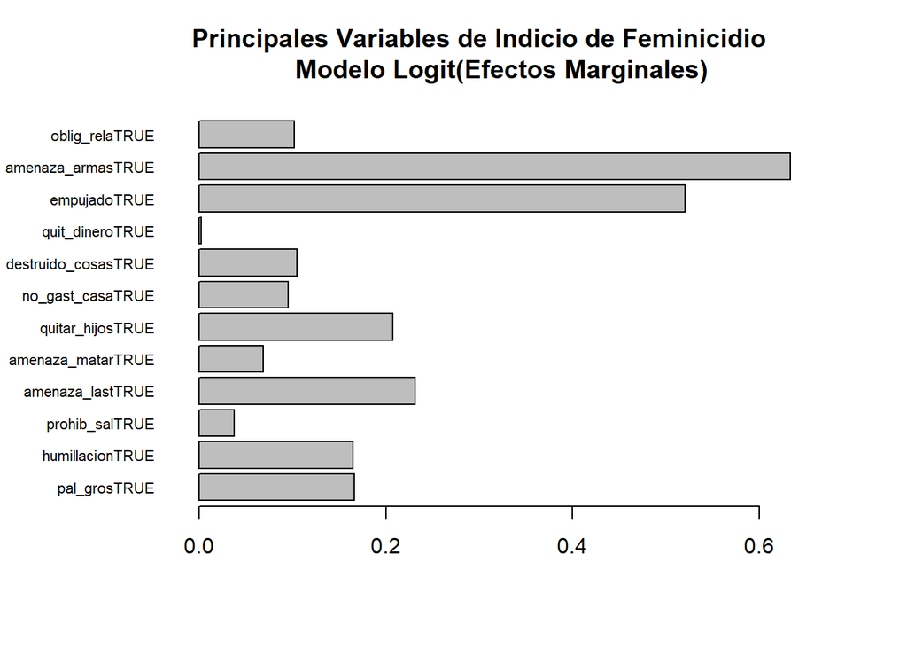

```r
info<-logitmfx(formula(m2),data=testbd)
barplot(info$mfxest[,1],horiz = T,las=1,cex.names = 0.7,xlim=c(-0.1,0.7),pos=-0.02)
title("Principales Variables de Indicio de Feminicidio
      Modelo Logit(Efectos Marginales)")
```